# Lab 4 Tidy data (50 points)

Fang Fang

Delivery:

1.Answer 8 questions in a word document.

2.You should also submit a .csv file as delivery as well.

3.You have 10 bonus points at the end of this lab.

### To start:

1. Create a new folder for lab4 and a subfolder called “output”, “data” inside lab4 folder.
2. Create a new project under lab4.
3. Go to File—New file—R script. Name it as Lab4_.r. Save this script under Lab4 folder.
4. Download the dataset from Canvas called “air_raw_upload.csv” and save it under the “data” subfolder.

Dataset information:

We will clean up the data downloaded from NSW Planning Industry & Environment website (https://www.dpie.nsw.gov.au/air-quality/search-for-and-download-air-quality-data). The meteorological variables was measured hourly in three stations: 1) WALLSEND; 2) NEWCASTLE; 3) BERESFIELD. The measured 5 types of meteorological variables are: 1) Wind speed; 2) Wind direction; 3) Air temperature; 4) Relative humidity; 5) Global solar radiation.

Ideally, the tidy dataset should look like:

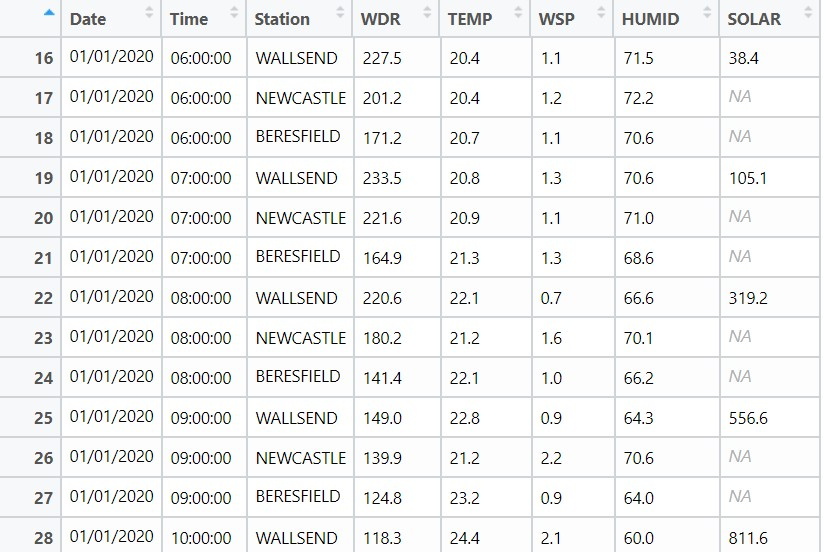

## Steps:

### 1. Import the dataset.

Download the dataset from here.

Download air_raw_upload.csv

Execute the code below to load the dataset. Ignore the warning messages.

```r
library(tidyverse)
air<- read_csv("data/air_raw_upload.csv")
```

Examine each column in this dataset and answer the questions below.

### Question 1: (5 points)

How many rows and columns does this dataset have?

### Question 2: (5 points)

Is this dataset tidy or messy? Why?

### Hint:

Let me provide you some initial thoughts here. The first few steps: `pivot_longer` (make your table longer. Organize multiple columns into one pair of columns) –separate (split the column contains multiple values).

### 2. Turn wide table into a long one. Name the output as air_v1.

First of all, you need to use `pivot_longer` to stack columns 3-17 together into two new columns.

1. For the first new column: name it “mix” to store the column names such as “WALLSEND WDR”.
2. For second new column: name it “measured_value” to store the corresponding value in that cell. .
3. You do not need to stack these columns: Date, Time.

Please complete your code in R and answer the questions.

### Question 3:(5 points)

How many rows and columns does air_v1 have?

```r
# Put your script below
```

### 3. Separate the column called mix.

Note under air_v1, there is a column called mix. This column merges two types of information: 1) station name; 2) meteorological variable. These two parts are separated by space.

Let’s use `separate` function to split these strings into two new columns.

1. Note you should set `sep` properly.
2. The old column to be separated is called “mix”.
3. For the two new columns, name them: “Station” and “Meteorological variable”.

Complete the code in your script window. Assign the new data as air_v2.

We are almost there.

### Question 4:(5 points)

Examine air_v2. Why is this dataset a messy data?

```r
# Put your script below
```

### Question 5: (10 points)

Based on your answer above, select one of the following functions `separate`, `unite`, `pivot_wider` to make air_v2 clean. Name the output as air_v3.

```r
# Put your script below
```

### Question 6: (5 points)

After you execute the function you choose above, How many rows and columns do you have for this clean dataset (air_v3)?

### Question 7:(10 points)

Among the three stations, which one has the highest average temperature?

Hint: Once your dataset is clean, let’s use `tapply` to calculate the average by 3 stations. You need to exclude the NAs.

Note you need to provide both your `tapply` code and answers for question 7.

```r
# Put your script below
```

### 4. Export and submit your assignment.

Let’s export this air_v3 as a .csv file on your local device. Name your file as yourname_lab4.csv.

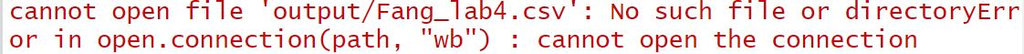

### Question 8:(5 points)

Submit this .csv file into Canvas as well

# This is the end of Lab 4.

### Bonus: (10 points)

1. Examine the output called air_v3. Does it still contain NAs? (5 points)

Answer:

2. Try to use `drop_na` function to exclude all the NAs in air_v3. Name the output air_v4. Export air_v4 as a csv and turn it in compass (5 points).

Hint: you can use `?drop_na` to know more about this function.

```r
# Put your script below
```